# Atividade-DataMining

# Pacotes utilizados.

rmdformats: para o estilo do markdown.

dplyr, tidyr e reshape2: para manipulação dos dados.

ggplot2: pacote para criar gráficos.

rpart: para criar árvore de decisão.

```r
library("rmdformats")
library("dplyr")
```

```r
library("tidyr")
library("ggplot2")
library("rpart")
library("reshape2")
```

# Sobre o dataset.

[figure not shown]

Image

Estarei utilizando o [dataset de receitas do site Epicurious](https://www.kaggle.com/datasets/hugodarwood/epirecipes) com valores nutricionais, avaliações da receita e as diferentes categorias que a receita se encaixa.

Este dataset possui algumas variáveis numéricas nutricionais e diversas variáveis categóricas do tipo dummy. Por isso, acredito que todas as análises poderiam ser contempladas neste único dataset, quebrando o dataset nas variáveis numéricas e categóricas.

```r
df <- read.csv("epi_r.csv")
head(df[,1:7])
```

```
##                                         title rating calories protein fat
## 1             Lentil, Apple, and Turkey Wrap   2.500      426      30   7
## 2 Boudin Blanc Terrine with Red Onion Confit   4.375      403      18  23
## 3               Potato and Fennel Soup Hodge   3.750      165       6   7
## 4            Mahi-Mahi in Tomato Olive Sauce   5.000       NA      NA  NA
## 5                   Spinach Noodle Casserole   3.125      547      20  32
## 6                              The Best Blts   4.375      948      19  79
##   sodium X.cakeweek
## 1    559          0
## 2   1439          0
## 3    165          0
## 4     NA          0
## 5    452          0
## 6   1042          0
```

# Pré-processamento de dados.

## Valores NA.

Primeiramente, iremos verificar quantos valores NA há no dataset.

```r
sum(apply(df, 1, anyNA))
```

```
## [1] 4188
```

Vimos que há diferentes formas para tratarmos isso. Uma das mais populares e simples é simplesmente removendo todas elas. Como ainda teremos muitos dados no nosso dataset, acredito que não teremos tanta perda com essa operação.

Podemos verificar a quantidade de valores antes e depois de retirar os valores ausentes.

```r
nrow(df)
```

```
## [1] 20052
```

```r
df <- drop_na(df)
nrow(df)
```

```
## [1] 15864
```

## Valores duplicados.

Outro problema comum é a presença de valores duplicados. Podemos utilizar o título da receita para verificar e removê-los.

```r
nrow(df)
```

```
## [1] 15864
```

```r
df <- subset(df, !duplicated(title))
nrow(df)
```

```
## [1] 14058
```

## Variáveis numéricas

Todas as variáveis deste dataframe, com exceção do título, são valores numéricos, mas nem todos eles iremos tratar como variáveis numéricas.

Talvez as mais chamativas sejam as variáveis binárias, apresetando apenas valores 0 ou 1. Iremos tratar todas elas como variáveis do tipo fator.

Além disso, pude perceber que a variável rating também não se comporta da mesma forma como as demais variáveis numéricas. Esta variável sempre assume um valor dentre 8 possibilidades. Podemos verificar isso utilizando a função unique().

```r
unique(sort(df$rating))
```

```
## [1] 0.000 1.250 1.875 2.500 3.125 3.750 4.375 5.000
```

Acredito que exista diferentes formas de se trabalhar com essa variável, podendo manter como uma variável numérica discreta ou considerando como uma variável categórica ordinal. Resolvi optar pela segunda opção e trabalhar como uma variável do tipo fator, pois no R podemos atribuir uma ordem em variáveis do tipo fator.

Assim, do dataframe temos as seguintes variáveis numéricas.

```r
df_num <- df[,3:6]
head(df_num)
```

```
##   calories protein fat sodium
## 1      426      30   7    559
## 2      403      18  23   1439
## 3      165       6   7    165
## 4      547      20  32    452
## 5      948      19  79   1042
## 6      170       7  10   1272
```

Para continuarmos tratando das variáveis numéricas, como fazer um feature selection ou aplicar transformações, precisamos verificar se há presença de outliers para não enviesar nossas análises.

Vamos primeiramente observar os boxplots de cada variável numérica.

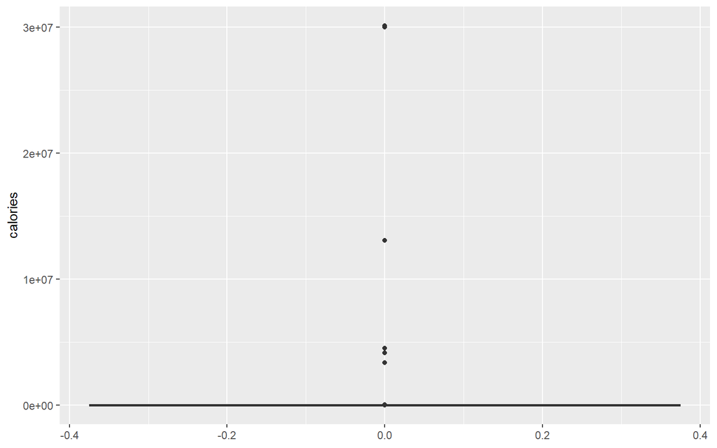

```r
ggplot(df_num,aes(y=calories))+
  geom_boxplot()
```

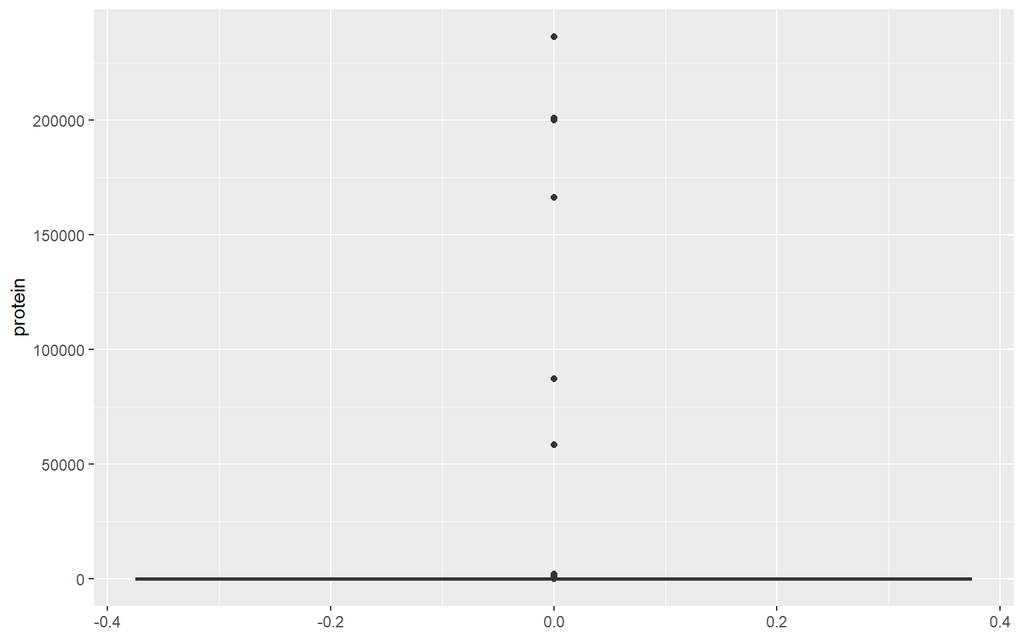

```r
ggplot(df_num,aes(y=protein))+
  geom_boxplot()
```

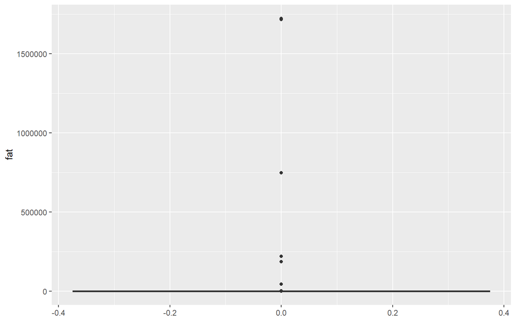

```r
ggplot(df_num,aes(y=fat))+
  geom_boxplot()
```

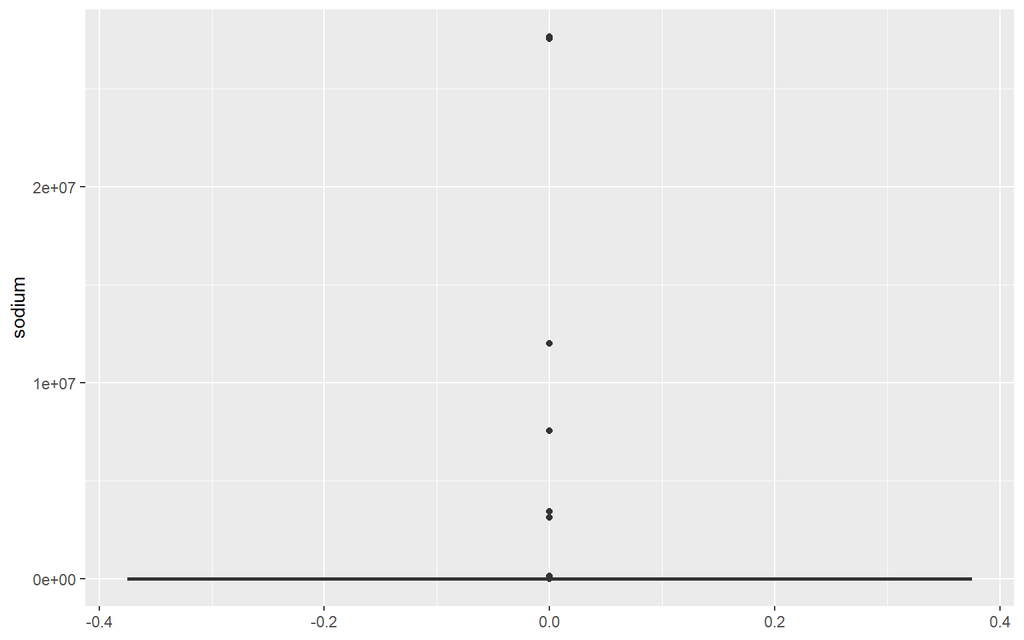

```r
ggplot(df_num,aes(y=sodium))+
  geom_boxplot()
```

Podemos observar que há uma presença muito extrema de outliers nessas variáveis que com certeza afetarão futuras análises.

Uma das formas de tratar os valores outliers seria aplicando o método IQR (intervalo interquartil) como visto em aula.

Vale ressaltar que como iremos remover esses valores outliers, precisaremos remover a linha toda do dataframe original, para que não tenha esta linha nas variáveis numéricas quanto nas variáveis categóricas.

Primeiramente, iremos criar uma função que transforme todos os outliers de cada variável em um valor NA para que possamos remover em seguida.

```r
replace_na_outliers_iqr <- function(x) {
  Q1 <- quantile(x, 0.25)
  Q3 <- quantile(x, 0.75)
  limite_inferior <- Q1 - 1.5 * IQR(x)
  limite_superior <- Q3 + 1.5 * IQR(x)
  x[x < limite_inferior | x > limite_superior] <- NA
  return(x)
}
```

```r
nrow(df)
```

```
## [1] 14058
```

```r
df[,3:6] <- as.data.frame(apply(df_num, 2, replace_na_outliers_iqr))
df <- drop_na(df)
nrow(df)
```

```
## [1] 12121
```

```r
df_num <- df[,3:6]
```

Agora podemos selecionar novamente as variáveis numéricas do dataset e verificar o boxplot de cada coluna.

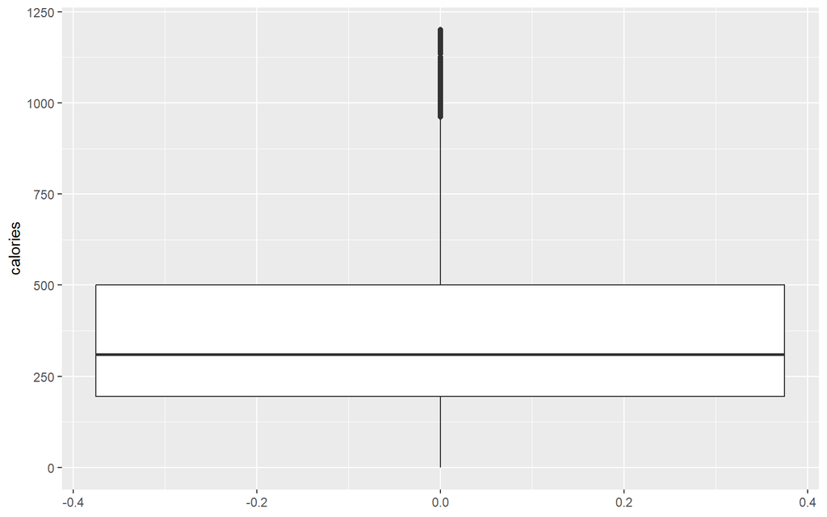

```r
ggplot(df_num,aes(y=calories))+
  geom_boxplot()
```

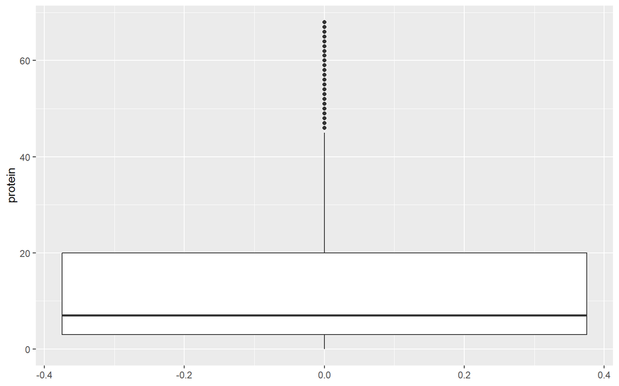

```r
ggplot(df_num,aes(y=protein))+
  geom_boxplot()
```

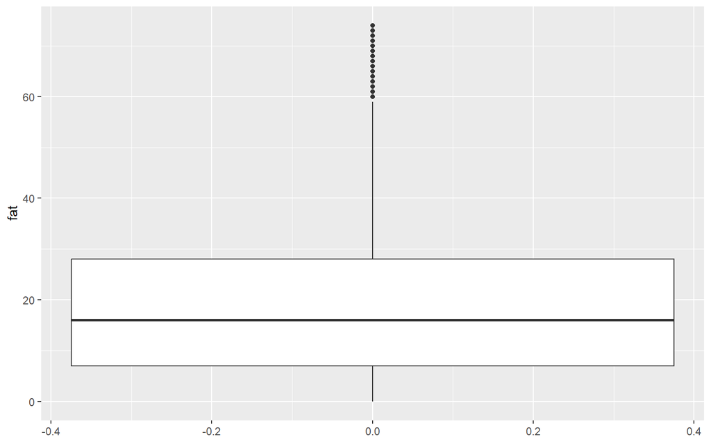

```r
ggplot(df_num,aes(y=fat))+
  geom_boxplot()
```

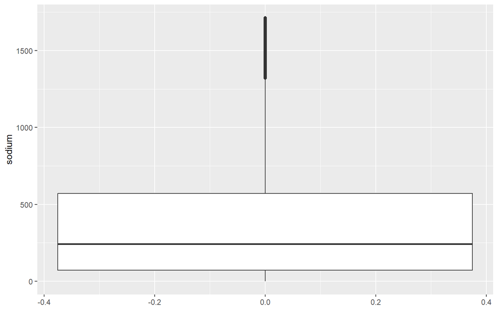

```r
ggplot(df_num,aes(y=sodium))+
  geom_boxplot()
```

Podemos ver que ainda há valores bem distantes da mediana dos dados, mas não necessariamente sejam outliers extremos que devemos tratar. Por isso, podemos manter os valores como estão.

## Variáveis categóricas.

As demais variáveis que não sejam o título ou as numéricas, estaremos encaixando como variáveis categóricas.

```r
df_cat_total <- df[,c(2,7:ncol(df))]
```

Porém, como todas elas possuem valores numéricos, à primeira vista o R identifica todas elas como variáveis numéricas.

```r
str(df_cat_total[1:6])
```

```
## 'data.frame':    12121 obs. of  6 variables:
##  $ rating               : num  2.5 4.38 3.75 3.12 4.38 ...
##  $ X.cakeweek           : num  0 0 0 0 0 0 0 0 0 0 ...
##  $ X.wasteless          : num  0 0 0 0 0 0 0 0 0 0 ...
##  $ X22.minute.meals     : num  0 0 0 0 0 0 0 0 0 0 ...
##  $ X3.ingredient.recipes: num  0 0 0 0 0 0 0 0 0 0 ...
##  $ X30.days.of.groceries: num  0 0 0 0 0 0 0 0 0 0 ...
```

Como iremos trabalhar com correlções em breve, pode ser útil manter como variáveis numéricas por mais tempo, mas até o fim do trabalho devemos transformar tudo em variável do tipo fator.

# Feature selection

Com os dados limpos, podemos trabalhar com a parte da seleção de variáveis.

## Variáveis numéricas

Uma das formas de selecionar variáveis numéricas é verificando se há variáveis altamente correlacionadas entre si.

Primeiramente, calculamos todas as combinações de correlações entre as variáveis numéricas dadas.

```r
corr_mat <- round(cor(df_num),3)
melted_corr_mat <- melt(corr_mat)
head(melted_corr_mat)
```

```
##       Var1     Var2 value
## 1 calories calories 1.000
## 2  protein calories 0.652
## 3      fat calories 0.837
## 4   sodium calories 0.435
## 5 calories  protein 0.652
## 6  protein  protein 1.000
```

Em seguida, plotamos um gráfico de calor para melhorar nossa visualização das correlações.

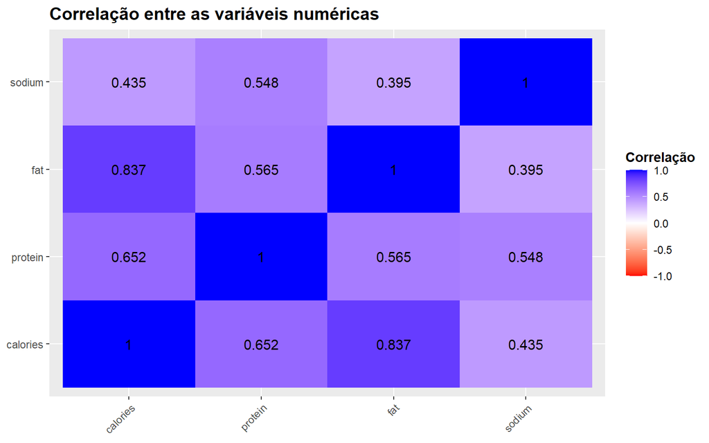

```r
ggplot(data = melted_corr_mat, aes(x=Var1, y=Var2,
                                   fill=value)) +
  geom_tile() +
  scale_fill_gradient2(low = "red", high = "blue", mid = "white", midpoint = 0, limit = c(-1, 1), space = "Lab",
                       name = "Correlação") +
  geom_text(aes(Var2, Var1, label = value),
            color = "black", size = 4) +
  theme(axis.text.x = element_text(angle=45, vjust = 1, hjust = 1)) +
  labs(title = "Correlação entre as variáveis numéricas") +
  theme(legend.title=element_text(face="bold"),
        plot.title= element_text(size=14,
                                 face="bold"),
        axis.title.x = element_blank(),
        axis.title.y = element_blank())
```

Podemos observar que há fortes relações positivas entre as variáveis nutricionais entre si. Em especial, há uma forte correlçao entre a variável calories e a variável fat, de 0.837.

Neste momento, é preciso realizar a decisão entre manter as variáveis ou remover uma delas. Dependendo do que é feito, é preciso que uma variável seja omitida para que não exista viés ao aplicar algum modelo. Mas isso ainda depende da relevância das variáveis para o estudo.

Como cada valor nutricional possui grande significado para uma refeição e como não temos nenhum objetivo mais profundo no momento, acredito que a melhor decisão seja manter todas essas variáveis presentes.

## Variáveis categóricas

Como há inúmeras variáveis categóricas neste dataset, esta é uma etapa crucial no projeto. Veremos como podemos selecionar nossas variáveis.

### Seleção manual

Dependendo do objetivo do estudo, já existem variáveis de interesse que devem ser utilizadas, como por exemplo se o o objetivo no estudo é sobre a comparação dos valores nutricionais e avaliações entre receitas veganas e não veganas, assim a categoria vegan deve ser inclusa.

Vale ressaltar que é interessante que exista um balanceamento de classes quando se aplica algum modelo envolvendo variáveis binárias, ou seja, a proporção de valores 0 e 1 deve ser próxima para que não tenha um viés de amostragem. Podemos dar uma olhada nas 30 variáveis que mais aparecem:

```r
soma <- sort(apply(df[,-c(1,2,3,4,5,6)],2,sum),decreasing = TRUE)
head(soma, n = 30)
```

```
##       bon.appétit       peanut.free          soy.free        vegetarian
##              5791              5361              5205              4638
##     tree.nut.free           gourmet            kosher       pescatarian
##              4394              4337              4125              4093
##      quick...easy wheat.gluten.free              bake            summer
##              3361              3110              3098              2651
##           dessert              side    no.sugar.added            winter
##              2475              2119              1919              1907
##              fall        dairy.free   kidney.friendly   sugar.conscious
##              1904              1898              1592              1504
##        milk.cream             fruit         vegetable             onion
##              1425              1360              1351              1321
##             sauté            tomato            dinner               egg
##              1319              1301              1264              1206
##             vegan      kid.friendly
##              1151              1070
```

Deixarei um exemplo de como essa escolha manual poderia ser feita. Vou selecionar algumas variáveis categóricas interessantes. Irei escolher as variáveis gourmet, winter, dessert, summer, fruit e vegan.

```r
cat_names <- c("rating","gourmet","winter","dessert","summer","fruit","vegan")
df_cat_manual <- df_cat_total[,cat_names]
```

### Seleção por ganho de informação

Outra forma interessante de feature selection de variáveis categóricas é por meio de ganho de informação. Porém, precisamos ter definido uma variável alvo para isso. Utilizaremos a variável rating.

Dessa forma, podemos aplicar um modelo de árvore de decisão para escolher as variáveis categóricas que são mais informativas em relação à avaliação da receita.

Aplicamos uma árvore de decisão usando o critério de entropia.

```r
arvore_decisao <- rpart(rating ~ .,
                        data = df_cat_total,
                        method = "class",
                        parms = list(split = "information"))
```

Em seguida, podemos observar quais são as variáveis que mais impactam na avaliação.

```r
print(arvore_decisao$variable.importance)
```

```
##         drink     alcoholic      cocktail non.alcoholic           gin
##     487.86565     360.10803     133.37334      92.65938      85.63973
##        spirit
##      83.53383
```

Acabamos chegando em variáveis que falam sobre bebidas alcoólicas no geral. Ou seja, possivelmente a distribuição de avaliações entre refeições e bebidas é bem diferente.

```r
df_cat_ad <- df_cat_total[,names(arvore_decisao$variable.importance)]
df_cat_ad <- cbind(df_cat_total$rating,df_cat_ad)
names(df_cat_ad)[1]<- "rating"
```

### Correlação entre variáveis categóricas

Como visto em aula, existem diferentes tipos de correlação. Um deles é a correlação de Kendall que pode ser utilizada entre variáveis categóricas. Assim, para complementar a seleção de atributos, podemos verificar a correlação das variáveis entre si.

Vamos primeiramente analisar as variáveis selecionadas manualmente.

```r
corr_mat <- round(cor(df_cat_manual,method = "kendall"),3)
melted_corr_mat <- melt(corr_mat)
head(melted_corr_mat)
```

```
##      Var1   Var2  value
## 1  rating rating  1.000
## 2 gourmet rating -0.033
## 3  winter rating  0.010
## 4 dessert rating  0.044
## 5  summer rating  0.017
## 6   fruit rating  0.032
```

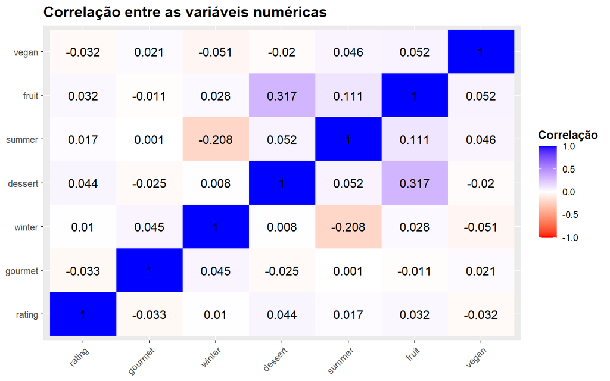

```r
ggplot(data = melted_corr_mat, aes(x=Var1, y=Var2,
                                   fill=value)) +
  geom_tile() +
  scale_fill_gradient2(low = "red", high = "blue", mid = "white", midpoint = 0, limit = c(-1, 1), space = "Lab",
                       name = "Correlação") +
  geom_text(aes(Var2, Var1, label = value),
            color = "black", size = 4) +
  theme(axis.text.x = element_text(angle=45, vjust = 1, hjust = 1)) +
  labs(title = "Correlação entre as variáveis numéricas") +
  theme(legend.title=element_text(face="bold"),
        plot.title= element_text(size=14,
                                 face="bold"),
        axis.title.x = element_blank(),
        axis.title.y = element_blank())
```

Vemos que praticamente não há correlações. Apenas uma fraca correlação positiva entre as variáveis fruta e sobremesa e uma fraca correlação negativa entre as variáveis verão e inverno.

Em seguida, podemos analisar as variáveis selecionadas pela árvore de decisão.

```r
corr_mat <- round(cor(df_cat_ad,method = "kendall"),3)
melted_corr_mat <- melt(corr_mat)
head(melted_corr_mat)
```

```
##            Var1   Var2  value
## 1        rating rating  1.000
## 2         drink rating -0.096
## 3     alcoholic rating -0.089
## 4      cocktail rating -0.048
## 5 non.alcoholic rating -0.031
## 6           gin rating -0.106
```

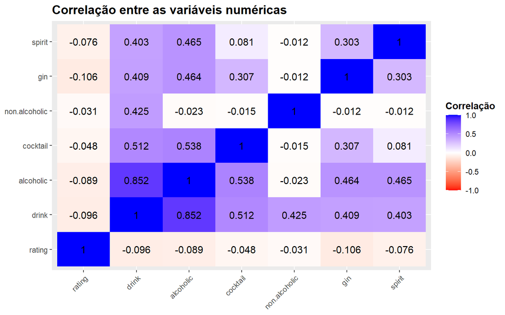

```r
ggplot(data = melted_corr_mat, aes(x=Var1, y=Var2,
                                   fill=value)) +
  geom_tile() +
  scale_fill_gradient2(low = "red", high = "blue", mid = "white", midpoint = 0, limit = c(-1, 1), space = "Lab",
                       name = "Correlação") +
  geom_text(aes(Var2, Var1, label = value),
            color = "black", size = 4) +
  theme(axis.text.x = element_text(angle=45, vjust = 1, hjust = 1)) +
  labs(title = "Correlação entre as variáveis numéricas") +
  theme(legend.title=element_text(face="bold"),
        plot.title= element_text(size=14,
                                 face="bold"),
        axis.title.x = element_blank(),
        axis.title.y = element_blank())
```

Podemos visualizar que há mais correlações positivas nessas variáveis, mesmo que não sejam tão fortes. As exceções são as variáveis drink e alcoólico que possuem uma forte correlação entre si.

Neste caso, são variáveis que num contexto de receitas, são praticamente sinônimos então faz sentido retirar uma das variáveis.

Iremos remover a variável drink.

```r
df_cat_ad <- df_cat_ad[,-2]
```

E agora podemos fazer a mudança nas variáveis. Para tal, iremos aplicar a função mutate() para alterar as variáveis para o tipo fator.

```r
df_cat_total <- df_cat_total %>%
  mutate(across(where(is.numeric), as.factor))
str(df_cat_total[1:6])
```

```
## 'data.frame':    12121 obs. of  6 variables:
##  $ rating               : Factor w/ 8 levels "0","1.25","1.875",..: 4 7 6 5 7 6 6 7 7 5 ...
##  $ X.cakeweek           : Factor w/ 2 levels "0","1": 1 1 1 1 1 1 1 1 1 1 ...
##  $ X.wasteless          : Factor w/ 2 levels "0","1": 1 1 1 1 1 1 1 1 1 1 ...
##  $ X22.minute.meals     : Factor w/ 2 levels "0","1": 1 1 1 1 1 1 1 1 1 1 ...
##  $ X3.ingredient.recipes: Factor w/ 2 levels "0","1": 1 1 1 1 1 1 1 1 1 1 ...
##  $ X30.days.of.groceries: Factor w/ 2 levels "0","1": 1 1 1 1 1 1 1 1 1 1 ...
```

```r
df_cat_manual <- df_cat_manual %>%
  mutate(across(where(is.numeric), as.factor))
str(df_cat_total[1:6])
```

```
## 'data.frame':    12121 obs. of  6 variables:
##  $ rating               : Factor w/ 8 levels "0","1.25","1.875",..: 4 7 6 5 7 6 6 7 7 5 ...
##  $ X.cakeweek           : Factor w/ 2 levels "0","1": 1 1 1 1 1 1 1 1 1 1 ...
##  $ X.wasteless          : Factor w/ 2 levels "0","1": 1 1 1 1 1 1 1 1 1 1 ...
##  $ X22.minute.meals     : Factor w/ 2 levels "0","1": 1 1 1 1 1 1 1 1 1 1 ...
##  $ X3.ingredient.recipes: Factor w/ 2 levels "0","1": 1 1 1 1 1 1 1 1 1 1 ...
##  $ X30.days.of.groceries: Factor w/ 2 levels "0","1": 1 1 1 1 1 1 1 1 1 1 ...
```

```r
df_cat_ad <- df_cat_ad %>%
  mutate(across(where(is.numeric), as.factor))
str(df_cat_total[1:6])
```

```
## 'data.frame':    12121 obs. of  6 variables:
##  $ rating               : Factor w/ 8 levels "0","1.25","1.875",..: 4 7 6 5 7 6 6 7 7 5 ...
##  $ X.cakeweek           : Factor w/ 2 levels "0","1": 1 1 1 1 1 1 1 1 1 1 ...
##  $ X.wasteless          : Factor w/ 2 levels "0","1": 1 1 1 1 1 1 1 1 1 1 ...
##  $ X22.minute.meals     : Factor w/ 2 levels "0","1": 1 1 1 1 1 1 1 1 1 1 ...
##  $ X3.ingredient.recipes: Factor w/ 2 levels "0","1": 1 1 1 1 1 1 1 1 1 1 ...
##  $ X30.days.of.groceries: Factor w/ 2 levels "0","1": 1 1 1 1 1 1 1 1 1 1 ...
```

# Algumas estatísticas e medidas de resumo dos dados;

Podemos visualizar algumas estatísticas básicas de resumo dos dados.

```r
summary(df_num)
```

```
##     calories         protein           fat            sodium
##  Min.   :   0.0   Min.   : 0.00   Min.   : 0.00   Min.   :   0.0
##  1st Qu.: 195.0   1st Qu.: 3.00   1st Qu.: 7.00   1st Qu.:  72.0
##  Median : 310.0   Median : 7.00   Median :16.00   Median : 243.0
##  Mean   : 364.3   Mean   :13.49   Mean   :19.47   Mean   : 377.1
##  3rd Qu.: 501.0   3rd Qu.:20.00   3rd Qu.:28.00   3rd Qu.: 571.0
##  Max.   :1201.0   Max.   :68.00   Max.   :74.00   Max.   :1713.0
```

```r
summary(df_cat_manual)
```

```
##      rating     gourmet  winter    dessert  summer   fruit     vegan
##  4.375  :5023   0:7784   0:10214   0:9646   0:9470   0:10761   0:10970
##  3.75   :3213   1:4337   1: 1907   1:2475   1:2651   1: 1360   1: 1151
##  5      :1481
##  0      : 979
##  3.125  : 934
##  2.5    : 333
##  (Other): 158
```

```r
summary(df_cat_ad)
```

```
##      rating     alcoholic cocktail  non.alcoholic gin       spirit
##  4.375  :5023   0:11590   0:11889   0:11981       0:11977   0:11982
##  3.75   :3213   1:  531   1:  232   1:  140       1:  144   1:  139
##  5      :1481
##  0      : 979
##  3.125  : 934
##  2.5    : 333
##  (Other): 158
```

# Análise exploratória inicial;

Podemos aplicar gráficos de histogramas nas variáveis numéricas e aplicar gráficos de barras nas categóricas para observar suas distribuições.

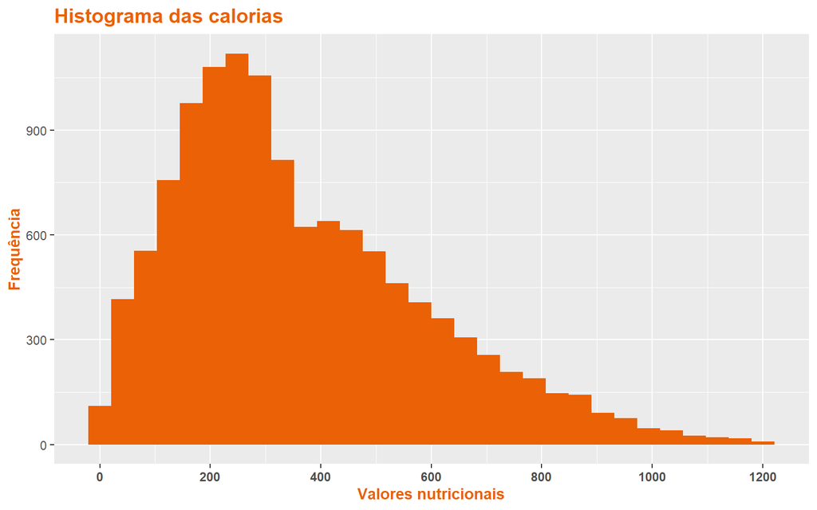

```r
ggplot(df_num, aes(x = calories, text = paste('Contagem:', ..count..))) + geom_histogram(bins = 30,fill = "#ea6106") + labs(x = "Valores nutricionais", y = "Frequência", title = "Histograma das calorias")+
 theme(plot.title= element_text(size=14,
                               color="#ea6106",
                               face="bold"),
      axis.title.x = element_text(face="bold",color="#ea6106"),
      axis.title.y = element_text(face="bold",color="#ea6106"),
       axis.text.x= element_text(face="bold")) +
scale_x_continuous(breaks = scales::pretty_breaks(n = 5))
```

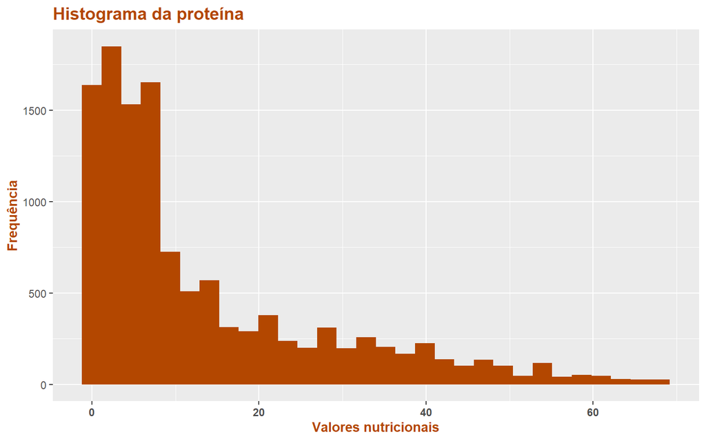

```r
ggplot(df_num, aes(x = protein, text = paste('Contagem:', ..count..))) + geom_histogram(bins = 30,fill = "#b34700") + labs(x = "Valores nutricionais", y = "Frequência", title = "Histograma da proteína")+
 theme(plot.title= element_text(size=14,
                               color="#b34700",
                               face="bold"),
      axis.title.x = element_text(face="bold",color="#b34700"),
      axis.title.y = element_text(face="bold",color="#b34700"),
       axis.text.x= element_text(face="bold")) +
scale_x_continuous(breaks = scales::pretty_breaks(n = 5))
```

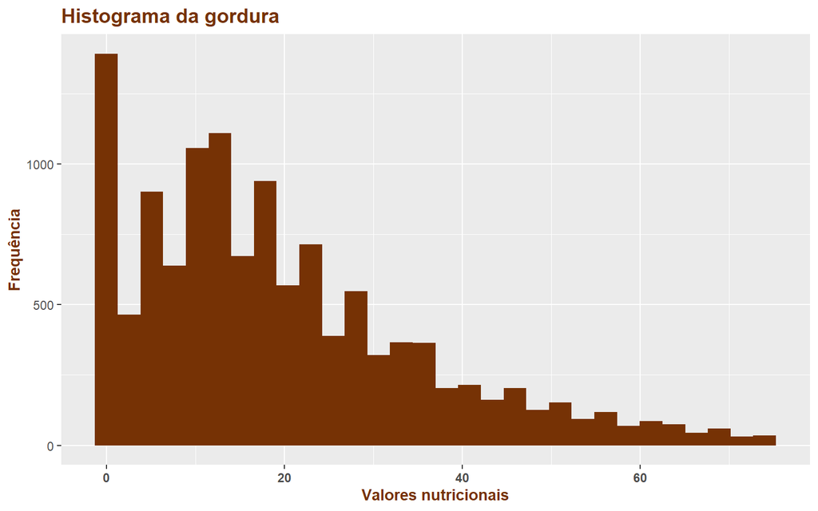

```r
ggplot(df_num, aes(x = fat, text = paste('Contagem:', ..count..))) + geom_histogram(bins = 30,fill = "#763205") + labs(x = "Valores nutricionais", y = "Frequência", title = "Histograma da gordura")+
 theme(plot.title= element_text(size=14,
                               color="#763205",
                               face="bold"),
      axis.title.x = element_text(face="bold",color="#763205"),
      axis.title.y = element_text(face="bold",color="#763205"),
       axis.text.x= element_text(face="bold")) +
scale_x_continuous(breaks = scales::pretty_breaks(n = 5))
```

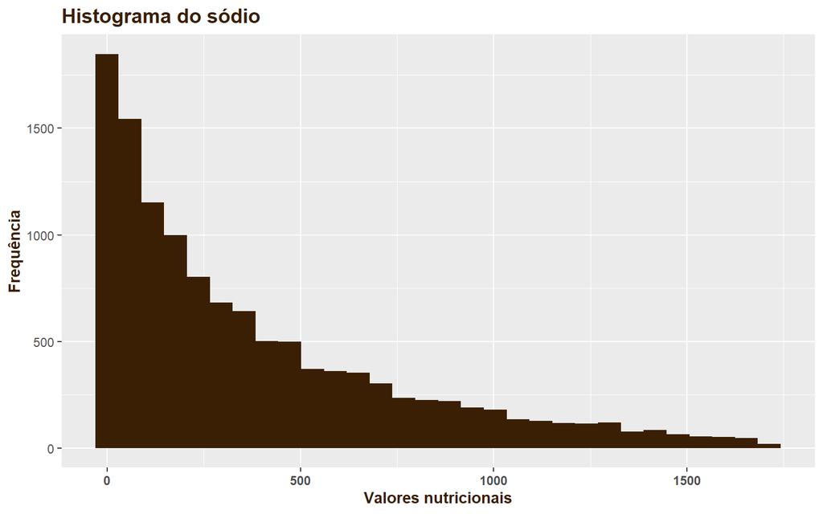

```r
ggplot(df_num, aes(x = sodium, text = paste('Contagem:', ..count..))) + geom_histogram(bins = 30,fill = "#3A1F05") + labs(x = "Valores nutricionais", y = "Frequência", title = "Histograma do sódio")+
 theme(plot.title= element_text(size=14,
                               color="#3A1F05",
                               face="bold"),
      axis.title.x = element_text(face="bold",color="#3A1F05"),
      axis.title.y = element_text(face="bold",color="#3A1F05"),
       axis.text.x= element_text(face="bold")) +
scale_x_continuous(breaks = scales::pretty_breaks(n = 5))
```

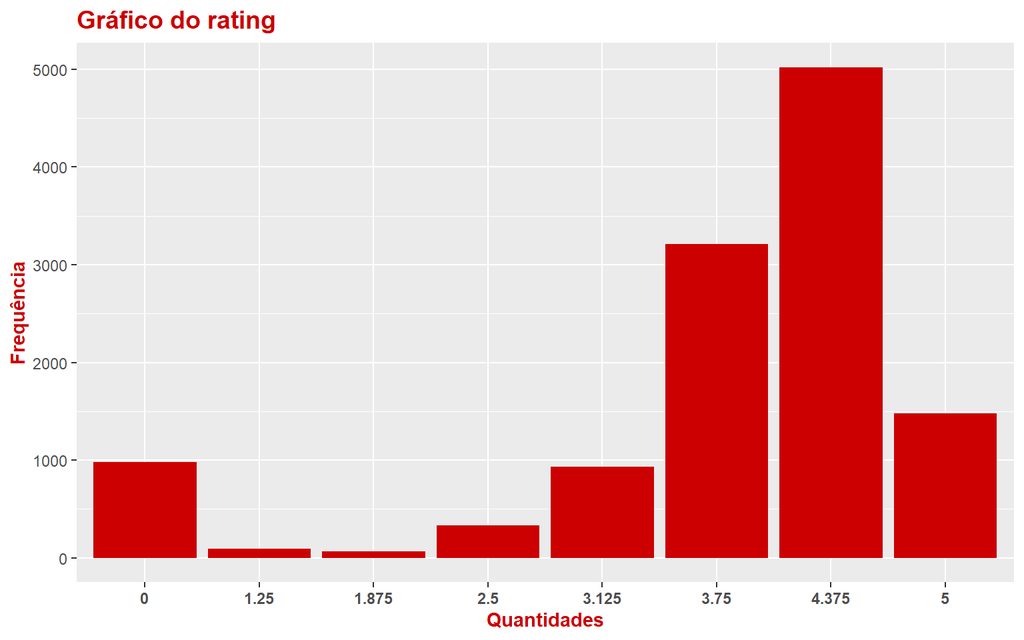

```r
ggplot(df_cat_manual, aes(x = rating, text = paste('Contagem:', ..count..))) + geom_bar(fill = "#cc0000") + labs(x = "Quantidades", y = "Frequência", title = "Gráfico do rating")+
 theme(plot.title= element_text(size=14,
                               color="#cc0000",
                               face="bold"),
      axis.title.x = element_text(face="bold",color="#cc0000"),
      axis.title.y = element_text(face="bold",color="#cc0000"),
       axis.text.x= element_text(face="bold"))
```

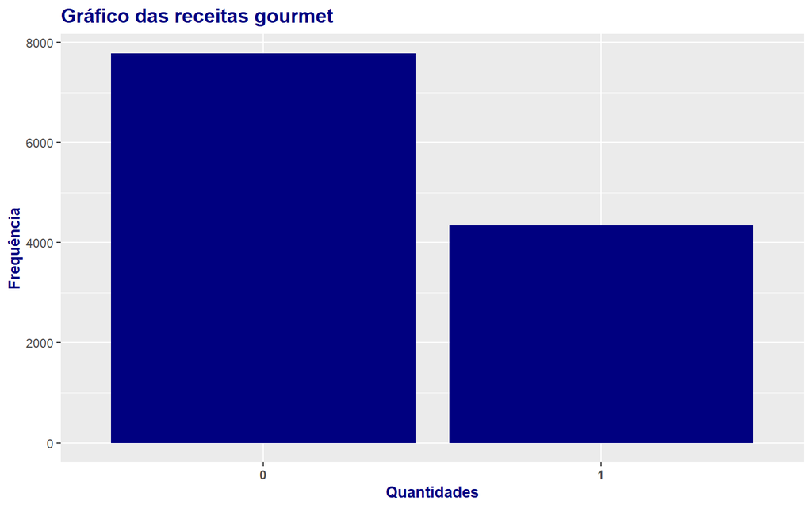

```r
ggplot(df_cat_manual, aes(x = gourmet, text = paste('Contagem:', ..count..))) + geom_bar(fill = "#000080") + labs(x = "Quantidades", y = "Frequência", title = "Gráfico das receitas gourmet")+
 theme(plot.title= element_text(size=14,
                               color="#000080",
                               face="bold"),
      axis.title.x = element_text(face="bold",color="#000080"),
      axis.title.y = element_text(face="bold",color="#000080"),
       axis.text.x= element_text(face="bold"))
```

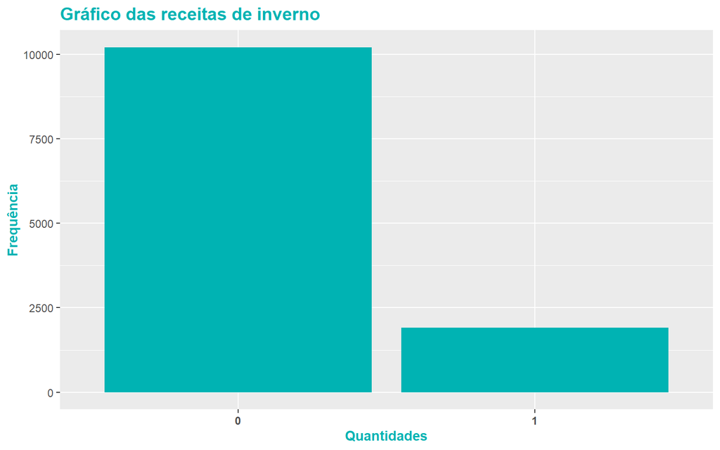

```r
ggplot(df_cat_manual, aes(x = winter, text = paste('Contagem:', ..count..))) + geom_bar(fill = "#00b3b3") + labs(x = "Quantidades", y = "Frequência", title = "Gráfico das receitas de inverno")+
 theme(plot.title= element_text(size=14,
                               color="#00b3b3",
                               face="bold"),
      axis.title.x = element_text(face="bold",color="#00b3b3"),
      axis.title.y = element_text(face="bold",color="#00b3b3"),
       axis.text.x= element_text(face="bold"))
```

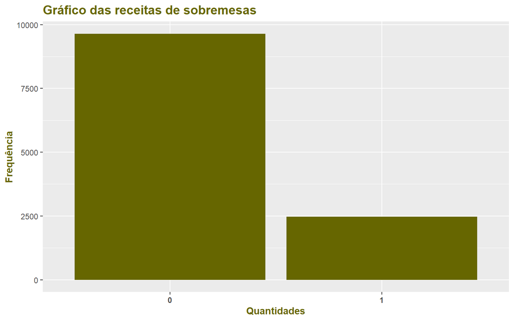

```r
ggplot(df_cat_manual, aes(x = dessert, text = paste('Contagem:', ..count..))) + geom_bar(fill = "#666600") + labs(x = "Quantidades", y = "Frequência", title = "Gráfico das receitas de sobremesas")+
 theme(plot.title= element_text(size=14,
                               color="#666600",
                               face="bold"),
      axis.title.x = element_text(face="bold",color="#666600"),
      axis.title.y = element_text(face="bold",color="#666600"),
       axis.text.x= element_text(face="bold"))
```

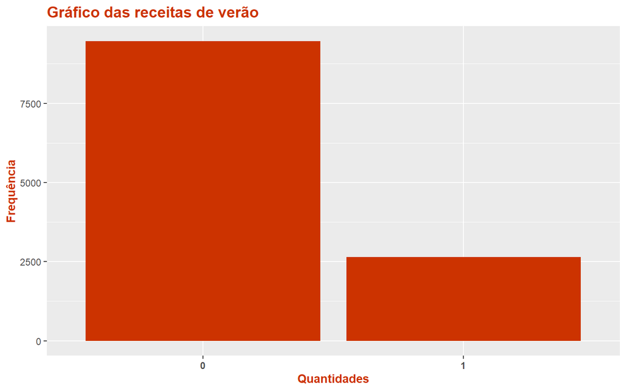

```r
ggplot(df_cat_manual, aes(x = summer, text = paste('Contagem:', ..count..))) + geom_bar(fill = "#cc3300") + labs(x = "Quantidades", y = "Frequência", title = "Gráfico das receitas de verão")+
 theme(plot.title= element_text(size=14,
                               color="#cc3300",
                               face="bold"),
      axis.title.x = element_text(face="bold",color="#cc3300"),
      axis.title.y = element_text(face="bold",color="#cc3300"),
       axis.text.x= element_text(face="bold"))
```

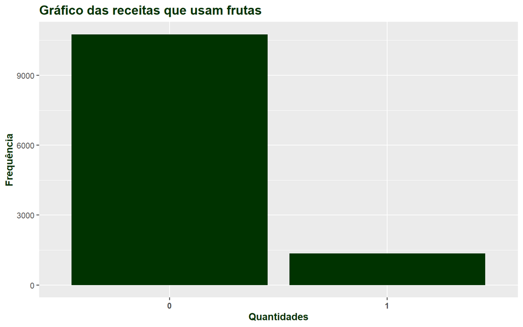

```r
ggplot(df_cat_manual, aes(x = fruit, text = paste('Contagem:', ..count..))) + geom_bar(fill = "#003300") + labs(x = "Quantidades", y = "Frequência", title = "Gráfico das receitas que usam frutas")+
 theme(plot.title= element_text(size=14,
                               color="#003300",
                               face="bold"),
      axis.title.x = element_text(face="bold",color="#003300"),
      axis.title.y = element_text(face="bold",color="#003300"),
       axis.text.x= element_text(face="bold"))
```

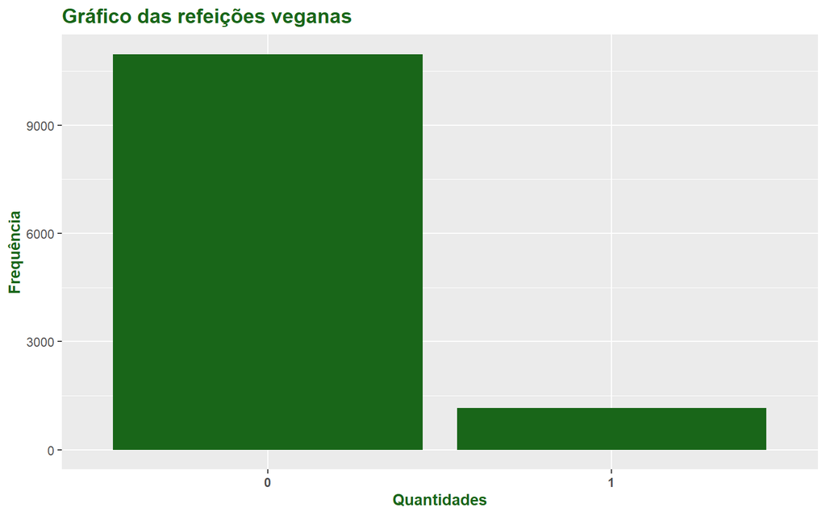

```r
ggplot(df_cat_manual, aes(x = vegan, text = paste('Contagem:', ..count..))) + geom_bar(fill = "#196619") + labs(x = "Quantidades", y = "Frequência", title = "Gráfico das refeições veganas")+
 theme(plot.title= element_text(size=14,
                               color="#196619",
                               face="bold"),
      axis.title.x = element_text(face="bold",color="#196619"),
      axis.title.y = element_text(face="bold",color="#196619"),
       axis.text.x= element_text(face="bold"))
```

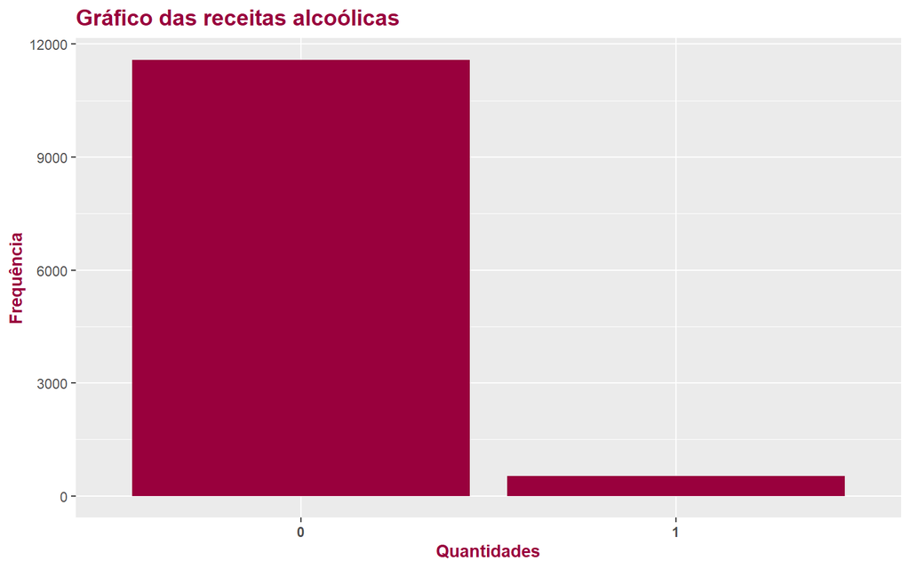

```r
ggplot(df_cat_ad, aes(x = alcoholic, text = paste('Contagem:', ..count..))) + geom_bar(fill = "#99003d") + labs(x = "Quantidades", y = "Frequência", title = "Gráfico das receitas alcoólicas")+
 theme(plot.title= element_text(size=14,
                               color="#99003d",
                               face="bold"),
      axis.title.x = element_text(face="bold",color="#99003d"),
      axis.title.y = element_text(face="bold",color="#99003d"),
       axis.text.x= element_text(face="bold"))
```

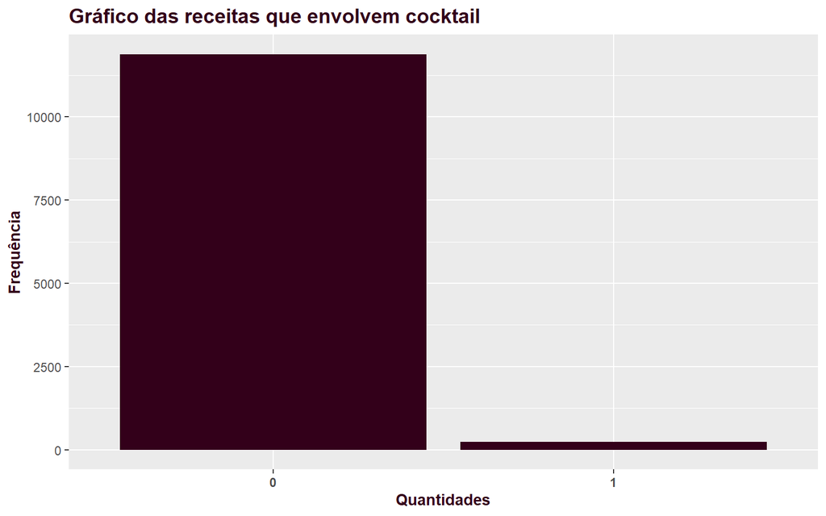

```r
ggplot(df_cat_ad, aes(x = cocktail, text = paste('Contagem:', ..count..))) + geom_bar(fill = "#33001a") + labs(x = "Quantidades", y = "Frequência", title = "Gráfico das receitas que envolvem cocktail")+
 theme(plot.title= element_text(size=14,
                               color="#33001a",
                               face="bold"),
      axis.title.x = element_text(face="bold",color="#33001a"),
      axis.title.y = element_text(face="bold",color="#33001a"),
       axis.text.x= element_text(face="bold"))
```

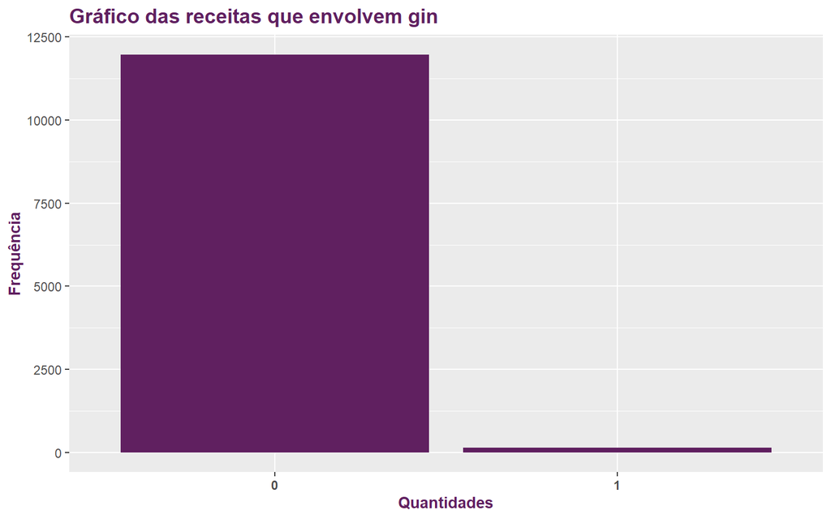

```r
ggplot(df_cat_ad, aes(x = gin, text = paste('Contagem:', ..count..))) + geom_bar(fill = "#602060") + labs(x = "Quantidades", y = "Frequência", title = "Gráfico das receitas que envolvem gin")+
 theme(plot.title= element_text(size=14,
                               color="#602060",
                               face="bold"),
      axis.title.x = element_text(face="bold",color="#602060"),
      axis.title.y = element_text(face="bold",color="#602060"),
       axis.text.x= element_text(face="bold"))
```

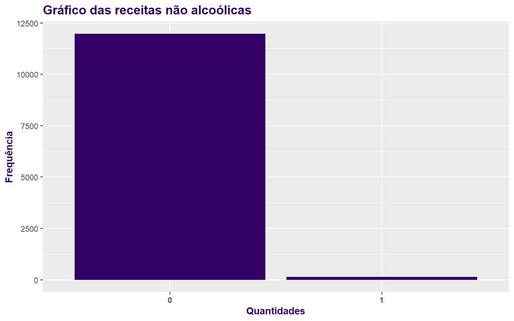

```r
ggplot(df_cat_ad, aes(x = non.alcoholic, text = paste('Contagem:', ..count..))) + geom_bar(fill = "#330066") + labs(x = "Quantidades", y = "Frequência", title = "Gráfico das receitas não alcoólicas")+
 theme(plot.title= element_text(size=14,
                               color="#330066",
                               face="bold"),
      axis.title.x = element_text(face="bold",color="#330066"),
      axis.title.y = element_text(face="bold",color="#330066"),
       axis.text.x= element_text(face="bold"))
```

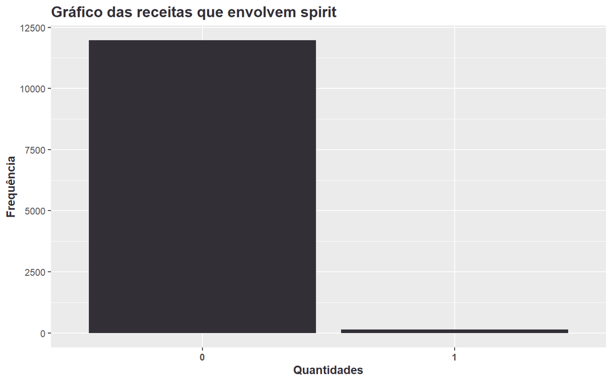

```r
ggplot(df_cat_ad, aes(x = spirit, text = paste('Contagem:', ..count..))) + geom_bar(fill = "#332f37") + labs(x = "Quantidades", y = "Frequência", title = "Gráfico das receitas que envolvem spirit")+
 theme(plot.title= element_text(size=14,
                               color="#332f37",
                               face="bold"),
      axis.title.x = element_text(face="bold",color="#332f37"),
      axis.title.y = element_text(face="bold",color="#332f37"),
       axis.text.x= element_text(face="bold"))
```